# README

#### Nick Mattson’s Class Repository for OCN-682

**Dept:** Botany  
**Degree Track:** MS  
**Research Interests:** I am interested in community ecology, specifically vegetation dynamics  
following ecological disturbance events. In a world impacted by climate change, understanding the responses  
of native plant communities to novel ecological stressors will impact planning and policy decisions.  
These dynamics are often poorly understood and new findings may change the way we understand  
anthropogenic impacts on ecological systems.

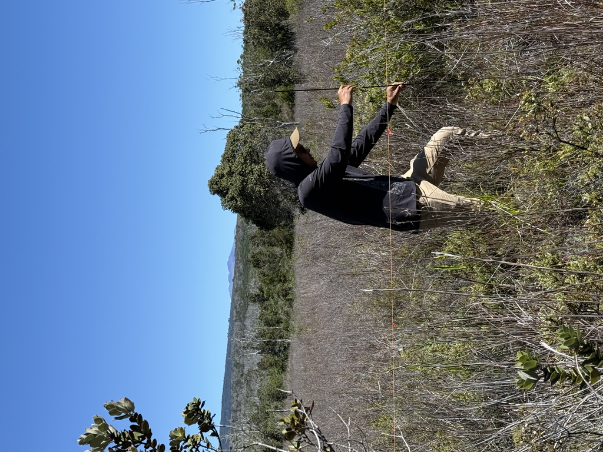

[Syllabus for Fall 2026](https://lamaku.hawaii.edu/d2l/le/content/176866/viewContent/4519241/View)

The purpose of this repository is:

Data Management * Learn good data foundations and organization * Gain fluency with RStudio and GitHub * Design readable graphics for my thesis

Thesis data design * Translate calculations from Google Sheets to reproducible R scripts * Synthesis of multiple datasets in one analysis

Weekly Folders: * [Week 2](https://github.com/OCN-682-UH/Mattson/tree/main/Week_02) * [Week 3](https://github.com/OCN-682-UH/Mattson/tree/main/Week_03) * [Week 4](https://github.com/OCN-682-UH/Mattson/tree/main/Week_04) * [Week 5](https://github.com/OCN-682-UH/Mattson/tree/main/Week_05) * [Week 6](https://github.com/OCN-682-UH/Mattson/tree/main/Week_06) * [Week 7](https://github.com/OCN-682-UH/Mattson/tree/main/Week_07) * [Week 8](https://github.com/OCN-682-UH/Mattson/tree/main/Week_08) * [Week 9](https://github.com/OCN-682-UH/Mattson/tree/main/Week_09)

Quarto Submissions * [Week 6 Quarto Class Practice](https://01a11368-0754-018c-ea5a-ce8440fc4a66.share.connect.posit.cloud/) * [Week 6 Quarto Submission](https://01a1133d-59e3-62e9-d795-fcd93422cd05.share.connect.posit.cloud/) * [Week 7 Quarto Submission](https://01a13734-21d9-7d46-bd41-5f2642e68e37.share.connect.posit.cloud/) * [Good Plot Bad Plot](https://01a157d4-052e-999d-9b83-4e6c574b4df9.share.connect.posit.cloud/) * [Week 8 Quarto Submission](https://01a15b5f-6a9f-4243-6d6e-24c46f9b41d5.share.connect.posit.cloud/) * [Week 9 Quarto Submission](https://01a17626-67cf-87b3-0c68-0f5a82137d2a.share.connect.posit.cloud/)

*Last edited by Nick Mattson on 10-20-2026*